# Figure S8

John Favate

2022-07-14 14:59:34

```r
# Prevent printing of warnings and such in the HTML
knitr::opts_chunk$set(warning = FALSE, message = FALSE)
```

```r
library(tidyverse)
library(patchwork)
library(scales)
library(rtracklayer)

go.df <- read_csv("../../data_frames/table_s10_go_results.csv")

# mutator order and levels
mut.levels <- read_csv("../../data_frames/all_data.csv") %>%
  dplyr::select(line, mutator) %>%
  arrange(mutator, line) %>%
  unique() %>%
  pull(line)

mut.colors <- c("black", rep("black", 5), rep("firebrick3", 5))

go.df$line <- factor(go.df$line, levels = mut.levels)

pps.df <- read_csv("../../data_frames/full_pps_data.csv")

kegg.df <- read_csv("../../data_frames/table_s9_kegg_results.csv")

all.data <- read_csv("../../data_frames/all_data.csv") %>%
  filter(gene_type == "ECB")
```

Find the top10 categories, i.e. those that are significant in the most lines.

```r
top.cats <- go.df %>%
  filter(ontology == "BP" & annotated <= 100 & !is.na(term)) %>%
  select(direction, ontology, term, total_sig, go.id) %>%
  unique() %>%
  arrange(desc(total_sig)) %>%
  dplyr::slice(1:10) %>%
  pull(term)

adf <- go.df %>%
  filter(term %in% top.cats) %>%
  mutate(cuts = cut(
    fisher,
    c(1, .05, .01, .001, .0001,-Inf),
    labels = c("****", "***", "**", "*", "")),
    term = factor(term, levels = rev(top.cats)
  ))
```

### Panel A

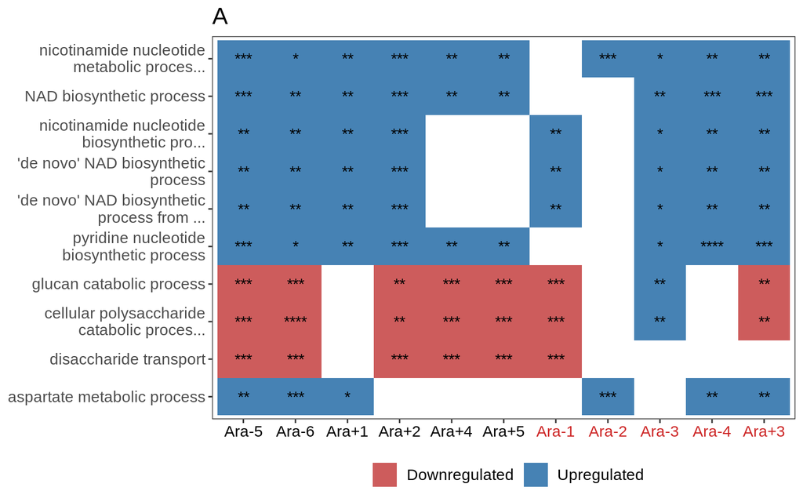

```r
pa <-  adf %>%
  ggplot(., aes(line, term, fill = direction, label = cuts))+
  geom_raster()+
  geom_text()+
  scale_fill_manual(values = c("indianred", "steelblue"), name = NULL, labels = c("Downregulated", "Upregulated"))+
  scale_y_discrete(labels = label_wrap(width = 30))+
  theme_bw()+
  theme(
    text = element_text(size = 14),
    legend.position = "bottom",
    axis.text.x = element_text(color = mut.colors),
    panel.grid = element_blank()
  )+
  labs(x = NULL, y = NULL, title = "A")

pa
```

### Panel B

RNAseq and riboseq enrichment scores and PPS scores are correlated. PPS:

```r
pps.rna.ribo.cors <- pps.df %>%                            #
  filter(type == "actual") %>%                             # keep actual PPS, not randomized
  select(pathway, line, pps, seqtype) %>%                  # retain these cols
  pivot_wider(names_from = seqtype, values_from = pps) %>% # reshape each seqtype has its own col
  split(.$line) %>%                                        # for each line
  map(function(x){                                         # compare the rna/ribo scores
    x %>%                                                  #
      select(-line, -pathway) %>%                          # remove these cols
      corrr::correlate(method = "spearman") %>%            # compare the RNAseq and riboseq cors
      .[2,2]                                               # pick the correlation, the others are redundancies
  }) %>%                                                   #
  bind_rows(.id ="line") %>%                               # recombine the data
  mutate(type = "PPS") %>%                                 # add a col that will differentiate from kegg
  dplyr::rename("rs" = "rna")                              #
```

Do the same for the kegg.

```r
sig.terms <- kegg.df %>%
  filter(seqtype == "ribo") %>%
  filter(qvalues <= .05) %>%
  group_by(description) %>%
  tally() %>%
  ungroup() %>%
  filter(!is.na(description)) %>%
  pull(description)

kegg.rna.ribo.cors <- kegg.df %>%                                      #
  filter(description %in% sig.terms) %>%                               # consider all significant terms in any line
  select(line, seqtype, id, enrichmentscore) %>%                       # retain these cols
  pivot_wider(names_from = seqtype, values_from = enrichmentscore) %>% # reshape to rna/ribo cols
  split(.$line) %>%                                                    # for each line
  map(function(x){                                                     # compare the rna/ribo scores
    x %>%                                                              #
      select(-line, -id) %>%                                           # remove these cols
      corrr::correlate(method = "spearman") %>%                        # correlate
      .[2,2]                                                           # pick the cor, the other are redundant
  }) %>%                                                               #
  bind_rows(.id ="line") %>%                                           # recombine the lines
  mutate(type = "Enrichment score") %>%                                # label to differentiate from pps
  dplyr::rename("rs" = "ribo")                                         # rename that col
```

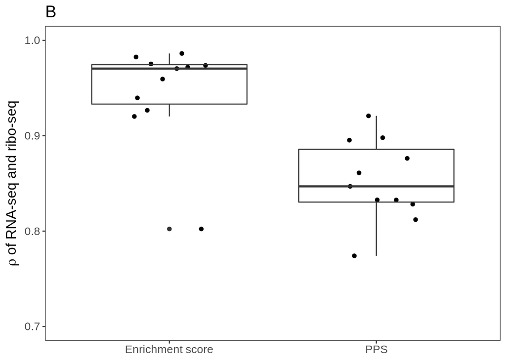

```r
pb <- bind_rows(kegg.rna.ribo.cors, pps.rna.ribo.cors) %>%
  ggplot(., aes(type, rs)) +
  geom_jitter(height = 0, width = .2) +
  geom_boxplot(fill = NA) +
  theme_bw() +
  theme(text = element_text(size = 14),
        panel.grid = element_blank()) +
  labs(x = NULL,
       y = expression(paste(rho, " of RNA-seq and ribo-seq")),
       title = "B") +
  scale_y_continuous(limits = c(.7, 1))

pb
```

### Panel C

The non-nadR regulated genes from fig 5A. This is long, because in order to make this document self contained it requires all the code from the other figure.

Read in the required items.

```r
# the list of mutations, and the specific clones for our mutations
my.mutations <- read_csv("../../data_frames/table_s12_mutations.csv")

# the ancestral gff
anc.gff <- readGFFAsGRanges("../../gffs/AraR6.gff")
```

The colors for the operon membership on the x axis

```r
mycolors <- c("#ad0008","#392bab","#839000","#009590","#ca991b","#302974","#dc2b2a","#008746","#7e0025","#a0a569","#9a4f00")
```

The following functions allow you to start with a vector of named genes where the elements of the vector are the names of the genes and the names of elements are operon membership. The actual names don’t matter, so long as they are different strings. This takes a few arguments  
x = named vector of genes  
title = title you want the heatmap to have, appears as a facet  
threshold = min/max fold change to show, a positive integer  
fig_letter = the figure letter, like A, B, C, etc  
x_labs = a vector of x labels, namely for underlining purposes  
The legend that appears with this is for the bottom mutations on genes plots, but it has to be made here

The colors for the mutation plots

```r
snp.color <- "darkorchid"
del.color <- "orange2"
ins.color <- "forestgreen"
```

```r
heatmap_function <- function(x, title, threshold, fig_letter, x_labs){
  # make a df that is keys for operons membership
  key.df <- enframe(x, value = "k12_name", name = "operon") %>%
    mutate(graph_label = title)

  # find fcs for those genes
  fcdf <- all.data %>%
    filter(k12_name %in% x) %>%
    mutate(stars = cut(
      ds_padj_rna,
      c(1, .05, .01, .001, .0001,-Inf),
      labels = c("****", "***", "**", "*", ""))) %>%
    dplyr::select(line, k12_name, ds_log2foldchange_rna, stars) %>%
    left_join(., key.df, by = "k12_name")

  # change min/max fcs to the threshold
  fcdf$ds_log2foldchange_rna[fcdf$ds_log2foldchange_rna > threshold] <- threshold
  fcdf$ds_log2foldchange_rna[fcdf$ds_log2foldchange_rna < -threshold] <- -threshold

  # factor x and y axis
  fcdf$line <- factor(fcdf$line, levels = mut.levels)
  fcdf$k12_name <- factor(fcdf$k12_name, levels = x)

  # create the color vector for the x axis
  # both number of colors (length(rep.vec)) and n times to repeat each color
  rep.vec <- table(key.df$operon)

  # make a vector where each color repeats the correct amount of times
  color.vec <- sapply(1:length(rep.vec), function(y){
    rep(mycolors[y], rep.vec[y])
  }) %>% unlist()

  # randomly add one of the three mutation types to the df, this is only for the purpose
  # of making their be a color legend of the bottom graph, the layer is drawn underneath
  # the heatmap so you can't actually see it but the legend shows, which is the intended
  # effect. seed ensures all three show up,

  set.seed(1)

  mut.vec <- sample(c("Deletion", "SNP", "Insertional\nelement"), nrow(fcdf), replace = TRUE)

  # add that column
  fcdf$mtype <- mut.vec

  # new color bar labels
  scale.labels <- c(paste("\u2264", paste0("-", threshold), sep = ""),
                    "",
                    0,
                    "",
                    paste("\u2265", threshold, sep = ""))

  # make clean colorbar breaks
  cbreaks <- c(-threshold,
               -threshold+(threshold/2),
               0,
               threshold-(threshold/2),
               threshold)

  # finally, make a graph
  plot <- fcdf %>%
    ggplot(., aes(k12_name, line, fill = ds_log2foldchange_rna, label = stars))+
    geom_point(aes(color = mtype))+
    geom_raster()+
    geom_text()+
    scale_fill_gradient2(low = "indianred", high = "steelblue",
                         name = expression(paste(log[2], "(FC)")),
                         limits = c(-threshold, threshold),
                         guide = guide_colorbar(ticks.colour = "black"),
                         breaks = cbreaks,
                         labels = scale.labels)+
    theme(text = element_text(size = 14),
          axis.text.x = element_text(color = color.vec),
          axis.text.y = element_text(color = mut.colors),
          panel.background = element_blank(),
          axis.ticks = element_blank(),
          legend.key = element_blank())+
    labs(x = NULL,
         y = NULL,
         title = fig_letter)+
    facet_wrap(~ graph_label)+
    scale_x_discrete(labels = x_labs)+
    scale_color_manual(values = c(del.color, ins.color, snp.color), name = "Mutation type", guide = "none")

  return(plot)
}
```

Finally, the genes

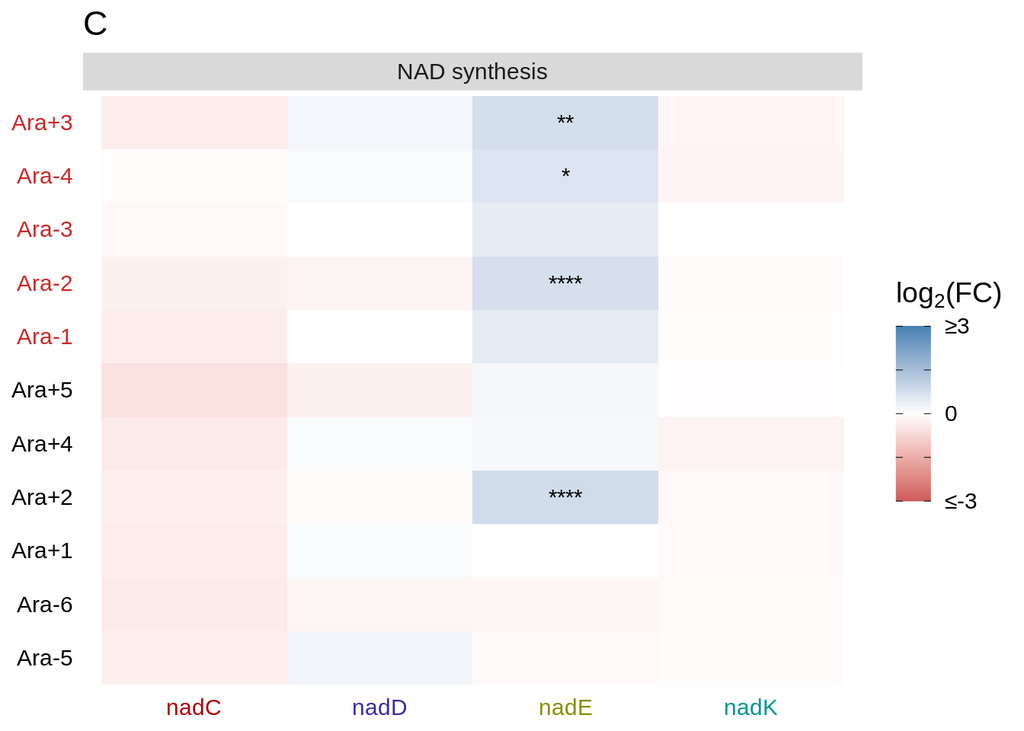

```r
nad <- c("nadC", "nadD", "nadE", "nadK")

names(nad) <- c("na", "nb", "nc", "nd")

nad.x.labs <- nad

pc <- heatmap_function(nad, title = "NAD synthesis", threshold = 3, fig_letter = "C", x_labs = nad.x.labs)

pc
```

### Panel D

Distribution of PPS scores

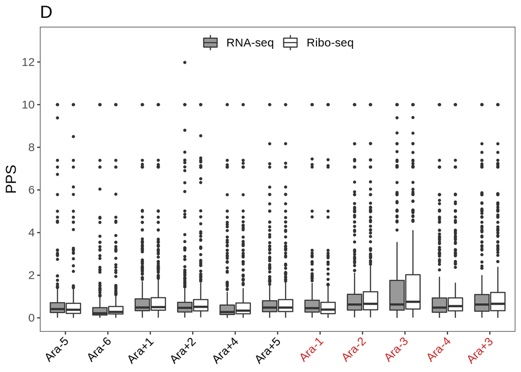

```r
pd <- pps.df %>%
  filter(iteration == "real") %>%
  mutate(line = factor(line, levels = c(mut.levels))) %>%
  ggplot(., aes(line, pps, fill = factor(seqtype, levels = c("rna", "ribo"))))+
  geom_boxplot(outlier.size = .75)+
  theme_bw()+
  theme(text = element_text(size = 14),
        panel.grid = element_blank(),
        axis.text.x =  element_text(angle = 45, vjust = 1.1, color = mut.colors, hjust = 1.1),
        legend.position = c(.5, .96),
        legend.background = element_blank())+
  labs(x = NULL,
       y = "PPS",
       title = "D")+
  scale_fill_manual(values = c("grey60", "white"), name = NULL, labels = c("RNA-seq", "Ribo-seq"))+
  guides(fill = guide_legend(nrow = 1))+
  scale_y_continuous(limits = c(0, 13), breaks = seq(0, 14, 2))

pd
```

### Final figure

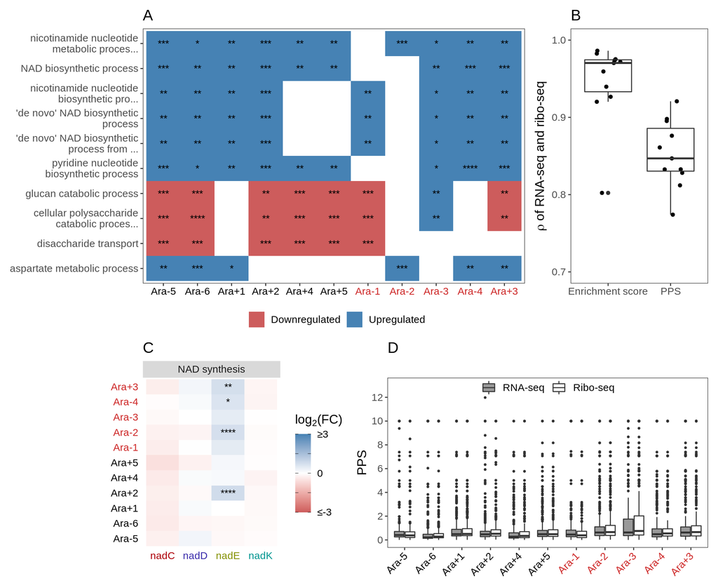

```r
layout <- "
AAAABB
CCDDDD
"

(ff <- (pa + pb + pc + pd) + plot_layout(design = layout, ncol = 2, heights = c(.6, .4)))
```

Save it

```r
write_rds(ff, "../../figures/fig_s8.rds")

ggsave(ff, filename = "../../figures/fig_s8.pdf", width = 11, height = 9)

ggsave(ff, filename = "../../figures/fig_s8.png", width = 11, height = 9)
```